# Lab 6

Random Forests/Bagging

Karlena Ochoa, Tamara Niella, Kathryn Denning

Assigned 5/20/20, Due 5/27/19

## Data

Read in the `train.csv` data.

- Because some of the models will take some time run, randomly sample 1% of the data (be sure to use `set.seed`).
- Remove the *classification* variable.

Read in the `fallmembershipreport_20192020.xlsx` data.

- Select `Attending School ID`, `School Name`, and all columns that represent the race/ethnicity percentages for the schools (there is example code in recent class slides).

Join the two data sets.

If you have accessed outside data to help increase the performance of your models for the final project (e.g., [NCES](https://nces.ed.gov/)), you can read in and join those data as well.

```r
set.seed(2000)
train <- read_csv(
    here::here("data", "edld-654-spring-2020", "train.csv")) %>%
    sample_frac(.01) %>%
    select(-classification)


sheets <- readxl::excel_sheets(here::here("data", "fallmembershipreport_20192020.xlsx"))

ode_schools <- readxl::read_xlsx(here::here("data", "fallmembershipreport_20192020.xlsx"), sheet = sheets[4])

ethnicities <- ode_schools %>%
  select(attnd_schl_inst_id = `Attending School ID`,
  attnd_dist_inst_id = `Attending District Institution ID`,
  sch_name = `School Name`,
  contains("%")) %>%
  janitor::clean_names()

names(ethnicities) <- gsub("x2019_20_percent", "p", names(ethnicities))

train_df <- left_join(train, ethnicities)
```

## Split and Resample

Split joined data from above into a training set and test set, stratified by the outcome `score`.

Use 10-fold CV to resample the training set, stratified by `score`.

```r
splt <- initial_split(train, strata = "score")
train <- training(splt)
cv <- vfold_cv(train, strata = "score")
```

## Preprocess

Create one `recipe` to prepare your data for CART, bagged tree, and random forest models.

This lab could potentially serve as a template for your **Premilinary Fit 2**, or your final model prediction for the **Final Project**, so consider applying what might be your best model formula and the necessary preprocessing steps.

```r
rec <- recipe(score ~ ., train) %>%
  step_mutate(tst_dt = lubridate::mdy_hms(tst_dt)) %>%
  update_role(contains("id"), ncessch, new_role = "id vars") %>%
  step_medianimpute(all_numeric(), -all_outcomes(), -has_role("id vars"))  %>%
  step_novel(all_nominal()) %>%
  step_unknown(all_nominal()) %>%
  step_nzv(all_predictors(), freq_cut = 0, unique_cut = 0)  %>%
  step_dummy(all_nominal())  %>%
  step_nzv(all_predictors())
```

## Decision Tree

1. Create a `parsnip` CART model using`{rpart}` for the estimation, tuning the cost complexity and minimum $n$ for a terminal node.

```r
dt_mod <- decision_tree() %>%
  set_mode("regression") %>%
  set_engine("rpart") %>%
  set_args(cost_complexity = tune(), min_n = tune())
```

2. Create a `workflow` object that combines your `recipe` and your `parsnip` objects. dt = dec tree

```r
dt_workflow <-
  workflow() %>%
  add_model(dt_mod) %>%
  add_recipe(rec)
```

3. Tune your model with `tune_grid`
- Use `grid = 10` to choose 10 grid points automatically
- In the `metrics` argument, please include `rmse`, `rsq`, and `huber_loss`
- Record the time it takes to run. You could use `{tictoc}`, or you could do something like:

```r
tic()

metrics_eval <- metric_set(rmse,
                           rsq,
                           huber_loss)


tune_tree <- tune_grid(dt_workflow,
                       cv,
                       metrics = metrics_eval)


toc()
```

```
## 42.94 sec elapsed
```

```r
#62.56 sec
```

4. Show the best estimates for each of the three tuning parameter and the tuning parameter values associated with each.

```r
show_best(tune_tree, metric = "rsq", n = 1)
```

```
## # A tibble: 1 x 7
##   cost_complexity min_n .metric .estimator  mean     n std_err
##             <dbl> <int> <chr>   <chr>      <dbl> <int>   <dbl>
## 1         0.00191    32 rsq     standard   0.243    10  0.0212
```

```r
show_best(tune_tree, metric = "rmse", n = 1)
```

```
## # A tibble: 1 x 7
##   cost_complexity min_n .metric .estimator  mean     n std_err
##             <dbl> <int> <chr>   <chr>      <dbl> <int>   <dbl>
## 1         0.00191    32 rmse    standard    102.    10    3.38
```

```r
show_best(tune_tree, metric = "huber_loss", n = 1)
```

```
## # A tibble: 1 x 7
##   cost_complexity min_n .metric    .estimator  mean     n std_err
##             <dbl> <int> <chr>      <chr>      <dbl> <int>   <dbl>
## 1         0.00191    32 huber_loss standard    78.5    10    2.31
```

## Bagged Tree

1. Create a `parsnip` bagged tree model using`{baguette}`
- specify 10 bootstrap resamples (only to keep run-time down), and
- tune on `cost_complexity` and `min_n`

```r
bt_mod <- bag_tree() %>%
  set_mode("regression") %>%
  set_args(cost_complexity = tune(), min_n = tune()) %>%
  set_engine("rpart", times = 10)
```

2. Create a `workflow` object that combines your `recipe` and your bagged tree model specification.

```r
bt_workflow <- dt_workflow %>%
  update_model(bt_mod)
bt_workflow
```

```
## == Workflow =======================================================================================================
## Preprocessor: Recipe
## Model: bag_tree()
##
## -- Preprocessor ---------------------------------------------------------------------------------------------------
## 7 Recipe Steps
##
## * step_mutate()
## * step_medianimpute()
## * step_novel()
## * step_unknown()
## * step_nzv()
## * step_dummy()
## * step_nzv()
##
## -- Model ----------------------------------------------------------------------------------------------------------
## Bagged Decision Tree Model Specification (regression)
##
## Main Arguments:
##   cost_complexity = tune()
##   min_n = tune()
##
## Engine-Specific Arguments:
##   times = 10
##
## Computational engine: rpart
```

3. Tune your model with `tune_grid`
- Use `grid = 10` to choose 10 grid points automatically
- In the `metrics` argument, please include `rmse`, `rsq`, and `huber_loss`
- In the `control` argument, please include `extract = function(x) extract_model(x)` to extract the model from each fit
- `{baguette}` is optimized to run in parallel with the `{future}` package. Consider using `{future}` to speed up processing time (see the class slides)
- Record the time it takes to run

```r
plan(multisession)

tic()

bt_tune_tree <- tune_grid(bt_workflow,
                       cv,
                       metrics = metrics_eval,
                       control= control_resamples(extract = function(x) extract_model(x)))


toc()
```

```
## 158.34 sec elapsed
```

```r
# 220.79 sec

plan(sequential)

bt_tune_tree %>%
  select(id, .metrics)%>%
  unnest(.metrics)
```

```
## # A tibble: 300 x 6
##    id     cost_complexity min_n .metric    .estimator .estimate
##    <chr>            <dbl> <int> <chr>      <chr>          <dbl>
##  1 Fold01    0.000125        13 rmse       standard     111.
##  2 Fold01    0.000125        13 rsq        standard       0.163
##  3 Fold01    0.000125        13 huber_loss standard      80.3
##  4 Fold01    0.000000105     39 rmse       standard     106.
##  5 Fold01    0.000000105     39 rsq        standard       0.205
##  6 Fold01    0.000000105     39 huber_loss standard      76.3
##  7 Fold01    0.0376          34 rmse       standard     111.
##  8 Fold01    0.0376          34 rsq        standard       0.127
##  9 Fold01    0.0376          34 huber_loss standard      84.0
## 10 Fold01    0.0000000160     6 rmse       standard     115.
## # ... with 290 more rows
```

4. Show the single best estimates for each of the three performance metrics and the tuning parameter values associated with each.

```r
show_best(bt_tune_tree, metric = "rsq", n = 1)
```

```
## # A tibble: 1 x 7
##   cost_complexity min_n .metric .estimator  mean     n std_err
##             <dbl> <int> <chr>   <chr>      <dbl> <int>   <dbl>
## 1     0.000000105    39 rsq     standard   0.291    10  0.0209
```

```r
show_best(bt_tune_tree, metric = "rmse", n = 1)
```

```
## # A tibble: 1 x 7
##   cost_complexity min_n .metric .estimator  mean     n std_err
##             <dbl> <int> <chr>   <chr>      <dbl> <int>   <dbl>
## 1     0.000000105    39 rmse    standard    97.4    10    2.97
```

```r
show_best(bt_tune_tree, metric = "huber_loss", n = 1)
```

```
## # A tibble: 1 x 7
##   cost_complexity min_n .metric    .estimator  mean     n std_err
##             <dbl> <int> <chr>      <chr>      <dbl> <int>   <dbl>
## 1     0.000000105    39 huber_loss standard    74.9    10    1.72
```

5. Run the `bag_roots` function below. Apply this function to the extracted bagged tree models from the previous step. This will output the feature at the root node for each of the decision trees fit.

```r
bag_roots <- function(x){
  x %>%
  select(.extracts) %>%
  unnest(cols = c(.extracts)) %>%
  mutate(models = map(.extracts,
                  ~.x$model_df)) %>%
  select(-.extracts) %>%
  unnest(cols = c(models)) %>%
  mutate(root = map_chr(model,
                     ~as.character(.x$fit$frame[1, 1]))) %>%
  select(root)
}


root_df <- bag_roots(bt_tune_tree)
```

6. Produce a plot of the frequency of features at the root node of the trees in your bagged model.

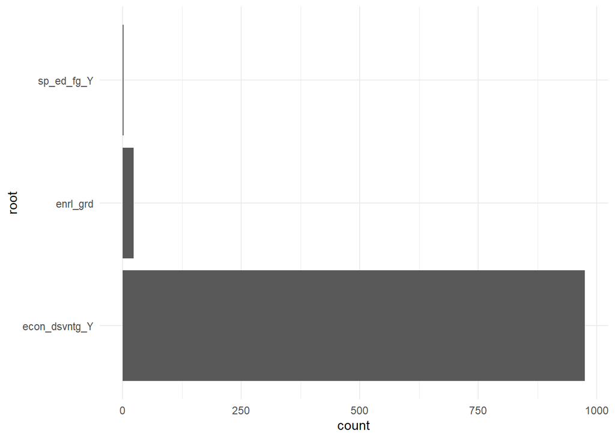

```r
ggplot(aes(root), data = root_df) +
  geom_bar() +
  coord_flip()
```